# task18

Milda Pieškutė

2016 m lapkritis 18 d

## Užduotis

Jums reikia atlikti paprastą tiesinę regresiją. Prognozuojamas kintamasis y, regresosrius x. Duomenų failas:

https://github.com/1vbutkus/Econometrics1/blob/master/task15/data.csv

#### 1-a dalis

Įvertinti tiesinės regresijos modelį.
$$y_{t} = \beta_{0} + \beta_{1}x_{t} + \beta_{2}x^2_{t}+\epsilon_{t}$$

Pateikti modelio `summary` ir pakomentuoti ką reiškia gauti skaičiai. Kaip interpretuoti gautus rezultatus?

```r
dt<-read.csv("https://raw.githubusercontent.com/1vbutkus/Econometrics1/master/task15/data.csv", header = TRUE)

x<-dt$x
y<-dt$y

quadratic.model<-lm(y~x+I(x^2))
summary(quadratic.model)
```

```
##
## Call:
## lm(formula = y ~ x + I(x^2))
##
## Residuals:
##       Min        1Q    Median        3Q       Max
## -0.046193 -0.013816  0.004572  0.013568  0.043686
##
## Coefficients:
##             Estimate Std. Error t value Pr(>|t|)
## (Intercept) 2.000764   0.002676  747.66   <2e-16 ***
## x           0.120730   0.009876   12.22   <2e-16 ***
## I(x^2)      0.972004   0.019229   50.55   <2e-16 ***
## ---
## Signif. codes:  0 '***' 0.001 '**' 0.01 '*' 0.05 '.' 0.1 ' ' 1
##
## Residual standard error: 0.02047 on 97 degrees of freedom
## Multiple R-squared:  0.9897, Adjusted R-squared:  0.9895
## F-statistic:  4652 on 2 and 97 DF,  p-value: < 2.2e-16
```

`Residuals` - nusako skirtumą tarp kintamojo tikrųjų reikšmių ir ir regresijos nustatytų. Daugeliu atvejų reikia, kad residuals primintų normalųjų skirstinį.

`Pr(>|t|)`-Kintamųjų p-reikšmės- nurodo tikimybę,kad kintamasis nėra reikšmingas. Turi būti kuo mažesnė ir mažesnė už pasirinktą reikšmingumo lygmenį.

`Estimate`-Estimated coefficient- regresija įvertintos $\beta$ reikšmės.

`Std. Error`-Standard error - matuoja koeficiento įverčio standartinį nuokrypį. Kuo mažesnis, tuo geriau. (Turėtų būti dukart mažesnis, nei coefficient estimate)

`Signif. codes` - žvaigždutės atitinka p reikšmę. *** reiškia, kad nedidelė tikimybė, jog nėra priklausomybės tarp y ir x.

`Residual standard error`- residuals standartinis nuokrypis. Turėtų būti proporcingas kvantiliams prie Residuals.

`Multiple R-squared`- matuoja goodness of fit. Kuo didesnis tuo geriau (iki 1).

`F-statistic`- F testo rezultatas. Tikrina, ar modelis su daugiau parametrų (dabartinis) geresnis, nei su mažiau.

#### 2-a dalis

Padarykite modelio prognozes taškuose (0, 0.3, 0.5).

```r
predict(quadratic.model,newdata=data.frame(x=c(0,0.3,0.5)))->pre
pre
```

```
##        1        2        3
## 2.000764 2.124464 2.304130
```

#### 3-a dalis

Išbrėžkite kintamųjų sklaidos diagramą kartu su tiesinės regresijos tiese ir naujomis prognozėmis. Grafiką pateikite su pilna legenda, kurioje būtų nurodyti visi žymėjimai.

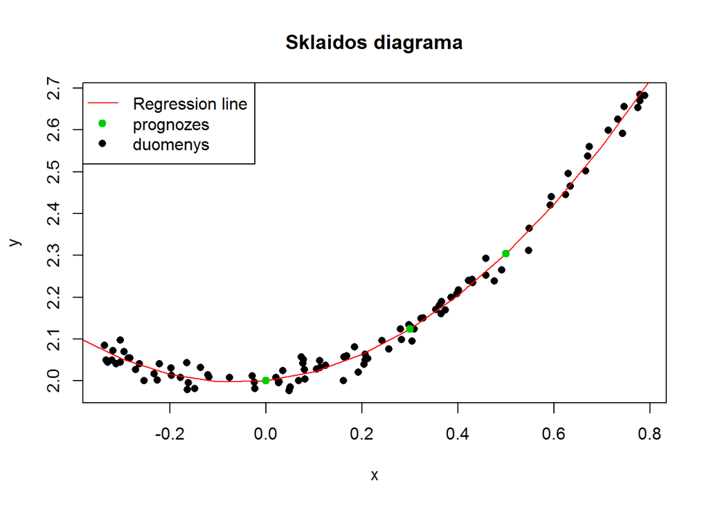

```r
xvalues<-seq(-0.5,2,0.1)
predictedcounts<-predict(quadratic.model, list(x=xvalues, x2=xvalues^2))
plot(x, y, pch=16, xlab="x", ylab="y",main="Sklaidos diagrama")
lines(xvalues, predictedcounts, col=2, lwd=1)
points(c(0,0.3,0.5), pre, col=3, pch=19)
legend("topleft", legend = c("Regression line","prognozes", "duomenys" ), col = c(2,3,1), lty = c(1,NA,NA), pch=c(NA, 19, 16) )
```

#### 4-a dalis

Pakomentuokite ar tinkamas šis modelis duotiems duomenims. Ar galite pateikti tobulinimo pasiūlymų?

Aš manau, kad taip. Patobulinimui pasiūlymų neturiu.

## Šaltiniai

http://blog.yhat.com/posts/r-lm-summary.html

http://www.theanalysisfactor.com/r-tutorial-4/